# Data Visualization

Buenas prácticas para un script:

- Poner la fecha
- Poner un título genérico.
- Cargar las librerías y copiar los datos devueltos en la consola para tenerlos como referencias para el futuro.

## Cargar librerías.

Entonces, en primer lugar vamos a cargar la librería **“tidyverse”**:

```r
library(tidyverse)
```

Como buena práctica, **es importante tener registrada la salida por consola para conocer el estado y versión de los paquetes cargados**.

Esto es lo que obtenemos a día de hoy:

- ── Attaching packages ──────────────────────────────────────────────── tidyverse 1.3.0 ──
- ✓ ggplot2 3.3.2 ✓ purrr 0.3.4
- ✓ tibble 3.0.4 ✓ dplyr 1.0.2
- ✓ tidyr 1.1.2 ✓ stringr 1.4.0
- ✓ readr 1.4.0 ✓ forcats 0.5.0 ── Conflicts ─────────────────────────────────────────────────── tidyverse_conflicts() ──
- x dplyr::filter() masks stats::filter()
- x dplyr::lag() masks stats::lag()

## Analisis preliminar: Cargar datos preestablecidos

Para comenzar a visualizar los datos, necesitamos datos y también preguntas sobre esos datos. Vamos a empezar con estos dos puntos:

**Preguntas**.

- Los coches con motor más grande ¿consumen más combustible que los coches con motor más pequeño?
- La relación consumo / tamaño ¿es lineal? ¿Es no lineal? ¿Es exponencial? ¿Es positiva? ¿Es negativa?

**Datos**.

Vamos a cargar un dataset que viene de serie en RStudio y que se llama **“mpg”**.

```r
ggplot2::mpg
```

| manufacturer | model | displ | year | cyl | trans | drv | cty | hwy | fl | class |
| --- | --- | --- | --- | --- | --- | --- | --- | --- | --- | --- |
| audi | a4 | 1.8 | 1999 | 4 | auto(l5) | f | 18 | 29 | p | compact |
| audi | a4 | 1.8 | 1999 | 4 | manual(m5) | f | 21 | 29 | p | compact |
| audi | a4 | 2.0 | 2008 | 4 | manual(m6) | f | 20 | 31 | p | compact |
| audi | a4 | 2.0 | 2008 | 4 | auto(av) | f | 21 | 30 | p | compact |
| audi | a4 | 2.8 | 1999 | 6 | auto(l5) | f | 16 | 26 | p | compact |
| audi | a4 | 2.8 | 1999 | 6 | manual(m5) | f | 18 | 26 | p | compact |
| audi | a4 | 3.1 | 2008 | 6 | auto(av) | f | 18 | 27 | p | compact |
| audi | a4 quattro | 1.8 | 1999 | 4 | manual(m5) | 4 | 18 | 26 | p | compact |
| audi | a4 quattro | 1.8 | 1999 | 4 | auto(l5) | 4 | 16 | 25 | p | compact |
| audi | a4 quattro | 2.0 | 2008 | 4 | manual(m6) | 4 | 20 | 28 | p | compact |

[output cut: 224 more lines]

Como podemos ver, hay coches y datos sobre los mismos (estos datasets vienen por defecto en R) y se puede saber que son datos ya que al cargar el código ggplot2::mpg se observa un icono de celdas. Sin embargo, verlo así es muy complicado por lo que es mejor ver la tabla completa con el comando “View” (lleva V mayúscula inicial):

```r
View(mpg)
```

Tras ejecutar este código tendremos una nueva pestaña donde se mostrará una rejilla con todos los datos necesarios.

Hay muchas columnas con muchos datos y nombres que es posible que nos sepamos su significado. Pero podemos consultar acerca del dataset con la siguiente instrucción:

```r
help(mpg)
```

Otra opción para realizar la misma consulta es:

```r
?mpg #Equivalente a help.
```

Por ahora nos quedamos con el recordatorio de dos nombres:

- **displ**: tamaño del motor del coche en litros
- **hwy**: número de millas recorridas en autopista por galón de combustible (3.785411784 litros).

## Primera representación

Vamos a hacer una primera representación con el siguiente código:

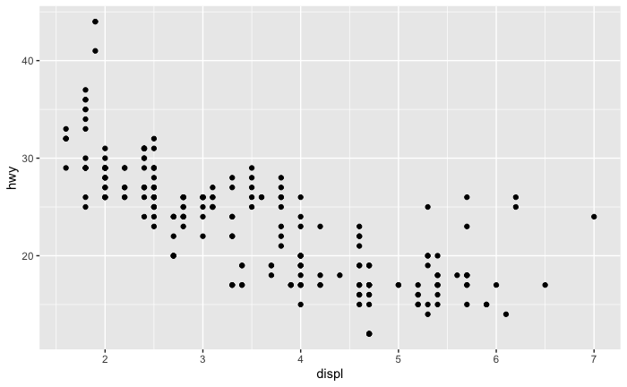

```r
ggplot(data = mpg) +
  geom_point(mapping = aes(x=displ, y = hwy))
```

Como podemos ver en la instrucción:

1. Llamamos a `ggplot()` y le indicamos que los datos a utilizar serán los del dataset (que ya tenemos cargado) **mpg**. En esta línea creamos el “entorno” de toda la gráfica y luego vamos agregando *capas* de información.
2. Agregamos un símbolo “+” que en este contexto significa que agregaremos más información a la instrucción.
3. Definimos el tipo de geometría de representación que queremos (en este caso, puntos = scatterplot o nube de puntos) y en la estética (aes) indicamos qué columna es $x$ y qué columna es $y$ así como las propiedades visuales.

**Cada vez que se use una propiedad “geom_lo-que-sea” hay que indicarle un “mapping” y un “aes”**.

## Primera conclusión: plantilla general

**PLANTILLA PARA HACER UNA REPRESENTACIÓN GRÁFICA CON GGPLOT**

ggplot(data = datos_a_representar) +  
geom_function(mapping = aes())

## Estéticas del gráfico

#### Colores

Vamos a generar un gráfico, donde nos interesaría agregar una nueva dimensión, donde podamos modificar ligeramente la estética del gráfico para resaltar algunas características en particular.

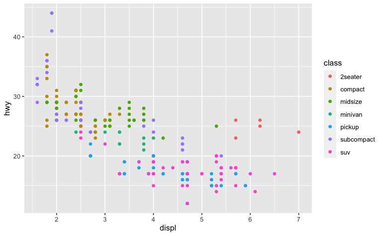

```r
ggplot(data = mpg) +
  geom_point(mapping = aes(x = displ, y =hwy, color = class))
```

En este caso, el color viene definido por la columna “class”, pintándose en un color diferente cada una de las clases/tipo (que son categorías) de coches. Si nos fijamos en el gráfico, parece que los coches con “mayor gasto” (mayor displ/potencia y gasto medio) son los coches de 2 asientos…probablemente deportivos.

#### Tamaño

Otra opción sería que el gráfico generara distintos conglomerados según el tipo de coche y eso podemos verlo con el comando *size*:

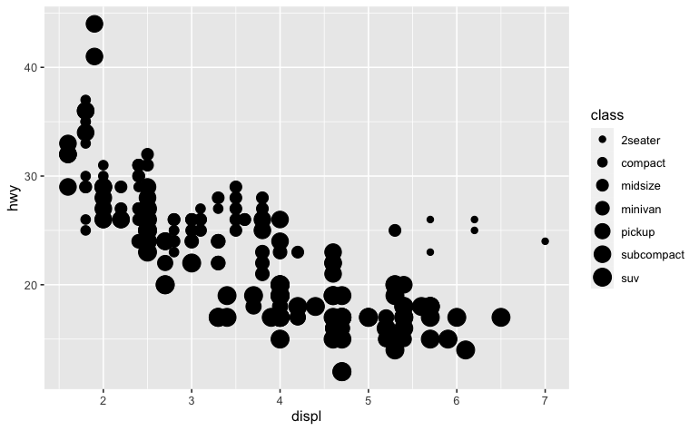

```r
ggplot(data=mpg) +
  geom_point(mapping = aes(x = displ, y =hwy, size = class))
```

Hay un aviso porque “size” es un comando que espera un tamaño (numérico) y nosotros le estamos pasando categorías (class).  
#### Transparencia de los puntos Para ello vamos a usar el comando “alpha”

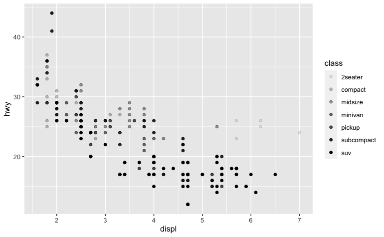

```r
ggplot (data = mpg) +
  geom_point (mapping = aes(x = displ,
                           y = hwy,
                           alpha = class
                           )
              )
```

#### Formas

También podríamos jugar con las formas de los puntos: asignar una forma a cada punto. El problema es que ggplot es capaz de manejar hasta un máximo de 6 formas bajo el parámetro “shape”. Veamos:

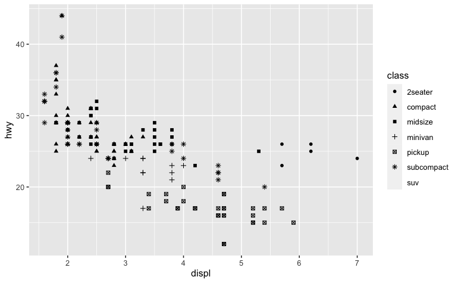

```r
ggplot(data = mpg) +
    geom_point(mapping = aes(x = displ,
                           y = hwy,
                           shape = class
                           )
               )
```

## Subgráficos usando variables categóricas

Hasta ahora habíamos usado variables discretas/categóricas para poner colores en un gráfico y también habíamos visto que muchas veces usar estas variables (categóricas) como parámetros del gráfico llevaba a “advertencias” (*warnings*). Por ello, en este apartado vamos a ver la instrucción **facets** para subdividir el gráfico en “facetas” siendo cada una de estas facetas una variable discreta.  
Por ejemplo: imaginemos que en lugar que querer un color en el gráfico por cada tipo de coche, realmente queremos un gráfico separado donde $x$ e $y$ sigan siendo las mismas pero queremos subgráficos con cada uno de los tipos de coche. En ese caso podemos usar *facets*. Así, en cada subgráfico, las variables representadas siguen siendo iguales pero se distribuyen según la variable categórica selecionada.  
La variable seleccionada se indica con una tilde ~ (altgr + ñ) y luego se pueden indicar el número de columnas (“ncol”) y filas ("“nrow”) en las que queremos que se distribuyan las gráficas.  
Veamos un ejemplo:

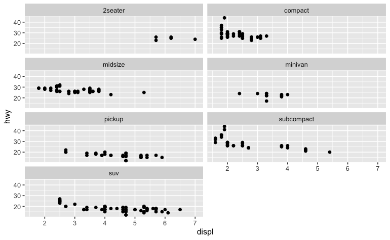

```r
ggplot(data = mpg) +
  geom_point(mapping = aes(x= displ,
                            y = hwy
                           )
             ) +
  facet_wrap(~class, nrow = 4)
```

En este gráfico, lo que se observa es que en todos los puntos el gasto en carretera y el displacement se grafica, pero se separa según una variable discreta que en este caso es *class*.